# Project13

For this project, I collected my data by scraping publicly available college football statistics from ESPN. I already had a copy of the dataset saved from earlier work, so I used the ESPN site to double‑check the numbers and make sure everything matched the official statistics before running my analysis.

For this project, I’m studying how 4th‑down efficiency and performance relate to overall team strength, and whether there’s a significant difference between the best and worst teams of that season.

(Rank) is a variable I added myself based on ESPN’s Football Power Index (FPI) for that year. FPI is a mathematical rating system that accounts for a team’s overall performance and efficiency. It’s more reliable than the AP Poll because it removes human opinion and focuses entirely on data.

(4th‑down efficiency) is measured using the number of 4th‑down attempts, conversions, and the conversion rate.

(4th‑down ranking) shows how each team ranks nationally on 4th‑down performance compared to other teams in the same season.

Before running my analysis I had to do several things to clean the data to make sure it was prepared for me. First thing I did was filter out the select teams that I wanted for the two seperate seaons - 2014 and 2020. My next step was to fix the column names in the 2020 data set and cros-referenced the ESPN official site to make sure I was labeling them correctly and the stats for the designated column was correct.I also built my own rank column for the teams using ESPNS' Football Power Index(FPI) since it was not originally included in the data set. Once I was able to cross reference everything and establish the validity of the data, I filtered out the specific rows that I wanted such as 'Wins' 'Rank' '4th down efficiency', etc so I wasnt dealing with 150 unnecessary columns.

```python
import pandas as pd
import seaborn as sns
import matplotlib.pyplot as plt
import numpy as np
import requests
import os
import statsmodels.api as sm
import statsmodels.formula.api as smf
from pathlib import Path
```

```python
data14=pd.read_csv(r"C:\Users\Admin\Downloads\archive (2)\cfb14.csv")
data20=pd.read_csv(r"C:\Users\Admin\Downloads\archive (2)\cfb20.csv")
data14.head()
```

|  | Team | Games | Win | Loss | Off.Rank | Off.Plays | Off.Yards | Off.Yards.Play | Off.TDs | Total.TDs | ... | Average.Time.of.Possession.per.Game | Turnover.Rank | Fumbles.Recovered | Opponents.Intercepted | Turnovers.Gain | Fumbles.Lost | Interceptions.Thrown.y | Turnovers.Lost | Turnover.Margin | Avg.Turnover.Margin.per.Game |
| --- | --- | --- | --- | --- | --- | --- | --- | --- | --- | --- | --- | --- | --- | --- | --- | --- | --- | --- | --- | --- | --- |
| 0 | Akron (MAC) | 12 | 5 | 7 | 88 | 891 | 4479 | 5.03 | 32 | 33 | ... | 29:05 | 76 | 11 | 13 | 24 | 12 | 14 | 26 | -2 | -0.17 |
| 1 | Alabama (SEC) | 14 | 12 | 2 | 17 | 1018 | 6783 | 6.66 | 67 | 68 | ... | 31:45 | 71 | 9 | 11 | 20 | 12 | 10 | 22 | -2 | -0.14 |
| 2 | Arizona (Pac-12) | 14 | 10 | 4 | 25 | 1139 | 6491 | 5.70 | 55 | 61 | ... | 27:13 | 26 | 13 | 13 | 26 | 8 | 10 | 18 | 8 | 0.57 |
| 3 | Arizona St. (Pac-12) | 13 | 10 | 3 | 34 | 975 | 5750 | 5.90 | 54 | 59 | ... | 28:42 | 6 | 13 | 14 | 27 | 4 | 9 | 13 | 14 | 1.08 |
| 4 | Arkansas (SEC) | 13 | 7 | 6 | 60 | 916 | 5278 | 5.76 | 52 | 56 | ... | 34:02 | 27 | 12 | 12 | 24 | 11 | 6 | 17 | 7 | 0.54 |

5 rows × 146 columns

```python
data20.head()
```

|  | Team | Games Played | Wins | Losses | Off.Rank | Off.Plays | Off.Yards | Off.Yards.Per.play | Off.TDs | Off.Yards.Per.Game | ... | Average.Time.of.Possession.per.Game | Turnover.Rank | Fumbles.Recovered | Opponents.Intercepted | Turnovers.Gain | Fumbles.Lost | Interceptions.Thrown.y | Turnovers.Lost | Turnover.Margin | Avg.Turnover.Margin.per.Game |
| --- | --- | --- | --- | --- | --- | --- | --- | --- | --- | --- | --- | --- | --- | --- | --- | --- | --- | --- | --- | --- | --- |
| 0 | Air Force (Mountain West) | 6 | 3 | 3 | 73 | 373 | 2336 | 6.26 | 19 | 389.3 | ... | 32:30 | 58 | 3 | 5 | 8 | 5 | 3 | 8 | 0 | 0.00 |
| 1 | Akron (MAC) | 6 | 1 | 5 | 121 | 360 | 1687 | 4.69 | 12 | 281.2 | ... | 30:35 | 98 | 4 | 2 | 6 | 3 | 6 | 9 | -3 | -0.50 |
| 2 | Alabama (SEC) | 11 | 11 | 0 | 5 | 764 | 5983 | 7.83 | 68 | 543.9 | ... | 30:45 | 12 | 10 | 11 | 21 | 7 | 4 | 11 | 10 | 0.91 |
| 3 | App State (Sun Belt) | 12 | 9 | 3 | 26 | 845 | 5424 | 6.42 | 49 | 452.0 | ... | 32:18 | 57 | 3 | 15 | 18 | 6 | 11 | 17 | 1 | 0.08 |
| 4 | Arizona (Pac-12) | 5 | 0 | 5 | 86 | 373 | 1847 | 4.95 | 10 | 369.4 | ... | 28:01 | 126 | 1 | 2 | 3 | 5 | 7 | 12 | -9 | -1.80 |

5 rows × 152 columns

```python
keep_teams = ['Oregon (Pac-12)', 'Alabama (SEC)', 'TCU (Big 12)', 'Ohio St. (Big Ten)', 'Georgia (SEC)', 'Baylor (Big 12)', 'Michigan St. (Big Ten)', 'Auburn (SEC)', 'Ole Miss ()', 'Mississippi St. (SEC)', 'UCLA (Pac-12)', 'Stanford (Pac-12)', 'Southern California (Pac-12)', 'FLorida St.(ACC)', 'LSU (SEC)', 'Oklahoma (Big 12)', 'Arkansas (SEC)', 'Kansas St. (Big 12)', 'Wisconsin (Big Ten)', 'Clemson (ACC)', 'Georgia Tech (ACC)', 'Florida (SEC)', 'Texas A&M (SEC)', 'Arizona St. (Pac-12)', 'Arizona (Pac-12)', 'Eastern Mich. (MAC)', 'Georgia St. (Sun Belt)', 'SMU (AAC)', 'New Mexico St. (Sun Belt)', 'Troy (Sun Belt)', 'Idaho (Sun Belt)', 'UNLV (WAC)', 'Miami (OH) (MAC)', 'Southern Miss. (C-USA)', 'UConn (AAC)', 'Massachusetts (MAC)', 'Kent St. (MAC)', 'Army West Point (FBS Independent)', 'Tulsa (AAC)', 'North Texas (C-USA)','FIU (C-USA)','Fla. Atlantic (C-USA)','Wake Forest (ACC)','Akron (MAC)','Buffalo (MAC)','Ohio (MAC)','Florida St. (ACC)']
data14_filtered = data14[data14['Team'].isin(keep_teams)]
len(data14_filtered)
```

```
45
```

```python
keep_teams = ['Oregon (Pac-12)', 'Alabama (SEC)', 'TCU (Big 12)', 'Ohio St. (Big Ten)', 'Georgia (SEC)', 'Iowa (Big Ten)', 'Texas (Big 12)', 'Auburn (SEC)', 'Notre Dame (ACC)', 'Miami (FL) (ACC)', 'Penn St. (Big Ten)', 'Iowa St. (Big 12)', 'Southern California (Pac-12)', 'BYU (FBS Independent)', 'Cincinnati (AAC)', 'Oklahoma (Big 12)', 'Indiana (Big Ten)', 'Oklahoma St. (Big 12)', 'Northwestern (Big Ten)', 'Clemson (ACC)', 'UCF (AAC)', 'Florida (SEC)', 'Texas A&M (SEC)', 'Arizona St. (Pac-12)', 'Syracuse (ACC)', 'Eastern Mich. (MAC)', 'Kansas (Big 12)', 'Vanderbilt (SEC)', 'Charlotte (C-USA)', 'Navy (AAC)', 'South Fla. (AAC)', 'Temple (AAC)', 'Texas St. (Sun Belt)', 'UTEP (C-USA)', 'Utah St. (Mountain West)', 'Massachusetts (FBS Independent)', 'South Alabama (Sun Belt)', 'UNLV (Mountain West)', 'Middle Tenn. (C-USA)', 'North Texas (C-USA)','FIU (C-USA)','Northern Ill. (MAC)','Southern Miss. (C-USA)','Akron (MAC)','Louisiana Tech (C-USA)','New Mexico (Mountain West)','Western Ky. (C-USA)','ULM (Sun Belt)','Bowling Green (MAC)','Wisconsin (Big Ten)']
data20_filtered = data20[data20['Team'].isin(keep_teams)]
len(data20_filtered)
```

```
50
```

```python
data20_filtered.head(50)
```

|  | Team | Games Played | Wins | Losses | Off.Rank | Off.Plays | Off.Yards | Off.Yards.Per.play | Off.TDs | Off.Yards.Per.Game | ... | Average.Time.of.Possession.per.Game | Turnover.Rank | Fumbles.Recovered | Opponents.Intercepted | Turnovers.Gain | Fumbles.Lost | Interceptions.Thrown.y | Turnovers.Lost | Turnover.Margin | Avg.Turnover.Margin.per.Game |
| --- | --- | --- | --- | --- | --- | --- | --- | --- | --- | --- | --- | --- | --- | --- | --- | --- | --- | --- | --- | --- | --- |
| 1 | Akron (MAC) | 6 | 1 | 5 | 121 | 360 | 1687 | 4.69 | 12 | 281.2 | ... | 30:35 | 98 | 4 | 2 | 6 | 3 | 6 | 9 | -3 | -0.50 |
| 2 | Alabama (SEC) | 11 | 11 | 0 | 5 | 764 | 5983 | 7.83 | 68 | 543.9 | ... | 30:45 | 12 | 10 | 11 | 21 | 7 | 4 | 11 | 10 | 0.91 |
| 5 | Arizona St. (Pac-12) | 4 | 2 | 2 | 20 | 252 | 1834 | 7.28 | 21 | 458.5 | ... | 29:01 | 1 | 8 | 5 | 13 | 4 | 1 | 5 | 8 | 2.00 |
| 9 | Auburn (SEC) | 10 | 6 | 4 | 75 | 685 | 3850 | 5.62 | 26 | 385.0 | ... | 29:10 | 33 | 4 | 9 | 13 | 1 | 7 | 8 | 5 | 0.50 |
| 14 | Bowling Green (MAC) | 5 | 0 | 5 | 111 | 314 | 1632 | 5.20 | 6 | 326.4 | ... | 26:24 | 127 | 1 | 0 | 1 | 4 | 7 | 11 | -10 | -2.00 |
| 16 | BYU (FBS Independent) | 12 | 11 | 1 | 7 | 799 | 6266 | 7.84 | 68 | 522.2 | ... | 29:57 | 19 | 10 | 8 | 18 | 5 | 4 | 9 | 9 | 0.75 |
| 19 | Charlotte (C-USA) | 6 | 2 | 4 | 81 | 416 | 2266 | 5.45 | 21 | 377.7 | ... | 34:18 | 42 | 3 | 5 | 8 | 4 | 2 | 6 | 2 | 0.33 |
| 20 | Cincinnati (AAC) | 9 | 9 | 0 | 19 | 612 | 4205 | 6.87 | 46 | 467.2 | ... | 32:04 | 37 | 4 | 15 | 19 | 9 | 6 | 15 | 4 | 0.44 |
| 21 | Clemson (ACC) | 11 | 10 | 1 | 10 | 831 | 5584 | 6.72 | 60 | 507.6 | ... | 30:52 | 17 | 9 | 13 | 22 | 8 | 5 | 13 | 9 | 0.82 |
| 27 | Eastern Mich. (MAC) | 6 | 2 | 4 | 61 | 418 | 2402 | 5.75 | 23 | 400.3 | ... | 29:12 | 58 | 9 | 3 | 12 | 6 | 6 | 12 | 0 | 0.00 |
| 28 | FIU (C-USA) | 5 | 0 | 5 | 122 | 306 | 1404 | 4.59 | 13 | 280.8 | ... | 26:12 | 76 | 1 | 2 | 3 | 2 | 2 | 4 | -1 | -0.20 |
| 30 | Florida (SEC) | 11 | 8 | 3 | 9 | 756 | 5597 | 7.40 | 56 | 508.8 | ... | 30:15 | 75 | 5 | 9 | 14 | 9 | 7 | 16 | -2 | -0.18 |
| 34 | Georgia (SEC) | 9 | 7 | 2 | 44 | 620 | 3792 | 6.12 | 35 | 421.3 | ... | 30:19 | 73 | 3 | 9 | 12 | 3 | 10 | 13 | -1 | -0.11 |
| 40 | Indiana (Big Ten) | 7 | 6 | 1 | 95 | 485 | 2507 | 5.17 | 26 | 358.1 | ... | 30:38 | 3 | 3 | 17 | 20 | 6 | 4 | 10 | 10 | 1.43 |
| 41 | Iowa (Big Ten) | 8 | 6 | 2 | 87 | 544 | 2949 | 5.42 | 27 | 368.6 | ... | 29:14 | 8 | 7 | 11 | 18 | 4 | 5 | 9 | 9 | 1.12 |
| 42 | Iowa St. (Big 12) | 11 | 8 | 3 | 31 | 743 | 4852 | 6.53 | 47 | 441.1 | ... | 32:11 | 58 | 6 | 8 | 14 | 5 | 9 | 14 | 0 | 0.00 |
| 43 | Kansas (Big 12) | 9 | 0 | 9 | 126 | 637 | 2333 | 3.66 | 16 | 259.2 | ... | 30:46 | 96 | 6 | 4 | 10 | 4 | 10 | 14 | -4 | -0.44 |
| 49 | Louisiana Tech (C-USA) | 10 | 5 | 5 | 116 | 703 | 3158 | 4.49 | 31 | 315.8 | ... | 30:11 | 76 | 5 | 9 | 14 | 2 | 14 | 16 | -2 | -0.20 |
| 54 | Massachusetts (FBS Independent) | 4 | 0 | 4 | 127 | 217 | 750 | 3.46 | 1 | 187.5 | ... | 25:15 | 118 | 3 | 0 | 3 | 2 | 5 | 7 | -4 | -1.00 |
| 56 | Miami (FL) (ACC) | 10 | 8 | 2 | 36 | 725 | 4326 | 5.97 | 40 | 432.6 | ... | 27:51 | 27 | 9 | 7 | 16 | 4 | 6 | 10 | 6 | 0.60 |
| 60 | Middle Tenn. (C-USA) | 9 | 3 | 6 | 89 | 636 | 3293 | 5.18 | 25 | 365.9 | ... | 29:33 | 80 | 6 | 8 | 14 | 6 | 10 | 16 | -2 | -0.22 |
| 64 | Navy (AAC) | 10 | 3 | 7 | 124 | 607 | 2750 | 4.53 | 21 | 275.0 | ... | 30:26 | 76 | 6 | 3 | 9 | 7 | 4 | 11 | -2 | -0.20 |
| 68 | New Mexico (Mountain West) | 7 | 2 | 5 | 64 | 504 | 2756 | 5.47 | 20 | 393.7 | ... | 30:32 | 28 | 7 | 6 | 13 | 3 | 6 | 9 | 4 | 0.57 |
| 70 | North Texas (C-USA) | 10 | 4 | 6 | 8 | 779 | 5132 | 6.59 | 46 | 513.2 | ... | 25:38 | 107 | 2 | 7 | 9 | 6 | 9 | 15 | -6 | -0.60 |
| 71 | Northern Ill. (MAC) | 6 | 0 | 6 | 88 | 442 | 2205 | 4.99 | 18 | 367.5 | ... | 33:39 | 98 | 2 | 5 | 7 | 8 | 2 | 10 | -3 | -0.50 |
| 72 | Northwestern (Big Ten) | 8 | 6 | 2 | 100 | 592 | 2789 | 4.71 | 23 | 348.6 | ... | 30:54 | 40 | 4 | 14 | 18 | 7 | 8 | 15 | 3 | 0.38 |
| 73 | Notre Dame (ACC) | 11 | 10 | 1 | 22 | 788 | 5007 | 6.35 | 46 | 455.2 | ... | 33:57 | 25 | 10 | 7 | 17 | 8 | 2 | 10 | 7 | 0.64 |
| 75 | Ohio St. (Big Ten) | 6 | 6 | 0 | 6 | 436 | 3175 | 7.28 | 31 | 529.2 | ... | 33:39 | 4 | 10 | 6 | 16 | 3 | 5 | 8 | 8 | 1.33 |
| 76 | Oklahoma (Big 12) | 10 | 8 | 2 | 18 | 716 | 4758 | 6.65 | 51 | 475.8 | ... | 32:52 | 39 | 3 | 13 | 16 | 4 | 8 | 12 | 4 | 0.40 |
| 77 | Oklahoma St. (Big 12) | 10 | 7 | 3 | 40 | 766 | 4277 | 5.58 | 30 | 427.7 | ... | 31:05 | 76 | 8 | 6 | 14 | 6 | 10 | 16 | -2 | -0.20 |
| 79 | Oregon (Pac-12) | 6 | 4 | 2 | 38 | 382 | 2578 | 6.75 | 26 | 429.7 | ... | 27:40 | 113 | 2 | 5 | 7 | 7 | 5 | 12 | -5 | -0.83 |
| 81 | Penn St. (Big Ten) | 9 | 4 | 5 | 37 | 709 | 3873 | 5.46 | 32 | 430.3 | ... | 33:41 | 110 | 6 | 4 | 10 | 8 | 9 | 17 | -7 | -0.78 |
| 89 | South Alabama (Sun Belt) | 11 | 4 | 7 | 94 | 770 | 3944 | 5.12 | 25 | 358.5 | ... | 30:22 | 70 | 7 | 7 | 14 | 9 | 6 | 15 | -1 | -0.09 |
| 91 | South Fla. (AAC) | 9 | 1 | 8 | 90 | 650 | 3288 | 5.06 | 23 | 365.3 | ... | 28:27 | 96 | 3 | 10 | 13 | 11 | 6 | 17 | -4 | -0.44 |
| 92 | Southern California (Pac-12) | 6 | 5 | 1 | 49 | 449 | 2500 | 5.57 | 25 | 416.7 | ... | 30:06 | 16 | 7 | 9 | 16 | 4 | 7 | 11 | 5 | 0.83 |
| 93 | Southern Miss. (C-USA) | 10 | 3 | 7 | 83 | 643 | 3720 | 5.79 | 30 | 372.0 | ... | 29:06 | 88 | 7 | 6 | 13 | 7 | 9 | 16 | -3 | -0.30 |
| 95 | Syracuse (ACC) | 11 | 1 | 10 | 125 | 656 | 2918 | 4.45 | 20 | 265.3 | ... | 24:17 | 47 | 11 | 13 | 24 | 9 | 12 | 21 | 3 | 0.27 |
| 96 | TCU (Big 12) | 10 | 6 | 4 | 51 | 685 | 4110 | 6.00 | 34 | 411.0 | ... | 30:09 | 52 | 7 | 8 | 15 | 8 | 5 | 13 | 2 | 0.20 |
| 97 | Temple (AAC) | 7 | 1 | 6 | 101 | 524 | 2438 | 4.65 | 16 | 348.3 | ... | 32:15 | 85 | 9 | 3 | 12 | 3 | 11 | 14 | -2 | -0.29 |
| 99 | Texas (Big 12) | 9 | 6 | 3 | 21 | 647 | 4116 | 6.36 | 45 | 457.3 | ... | 27:40 | 18 | 8 | 8 | 16 | 4 | 5 | 9 | 7 | 0.78 |
| 100 | Texas A&M (SEC) | 9 | 8 | 1 | 33 | 617 | 3935 | 6.38 | 36 | 437.2 | ... | 35:06 | 31 | 4 | 9 | 13 | 4 | 4 | 8 | 5 | 0.56 |
| 101 | Texas St. (Sun Belt) | 12 | 2 | 10 | 85 | 778 | 4436 | 5.70 | 41 | 369.7 | ... | 25:50 | 82 | 8 | 7 | 15 | 4 | 14 | 18 | -3 | -0.25 |
| 108 | UCF (AAC) | 10 | 6 | 4 | 2 | 859 | 5681 | 6.61 | 55 | 568.1 | ... | 27:30 | 7 | 13 | 9 | 22 | 6 | 4 | 10 | 12 | 1.20 |
| 110 | ULM (Sun Belt) | 10 | 0 | 10 | 119 | 631 | 3057 | 4.84 | 23 | 305.7 | ... | 27:16 | 112 | 7 | 4 | 11 | 7 | 12 | 19 | -8 | -0.80 |
| 111 | UNLV (Mountain West) | 6 | 0 | 6 | 108 | 420 | 1983 | 4.72 | 13 | 330.5 | ... | 29:18 | 108 | 3 | 2 | 5 | 5 | 4 | 9 | -4 | -0.67 |
| 113 | Utah St. (Mountain West) | 6 | 1 | 5 | 123 | 362 | 1655 | 4.57 | 10 | 275.8 | ... | 25:56 | 118 | 2 | 2 | 4 | 5 | 5 | 10 | -6 | -1.00 |
| 114 | UTEP (C-USA) | 8 | 3 | 5 | 102 | 539 | 2785 | 5.17 | 23 | 348.1 | ... | 32:41 | 114 | 6 | 2 | 8 | 6 | 9 | 15 | -7 | -0.88 |
| 116 | Vanderbilt (SEC) | 9 | 0 | 9 | 110 | 630 | 2970 | 4.71 | 17 | 330.0 | ... | 29:42 | 115 | 7 | 2 | 9 | 6 | 11 | 17 | -8 | -0.89 |
| 123 | Western Ky. (C-USA) | 11 | 5 | 6 | 120 | 699 | 3200 | 4.58 | 21 | 290.9 | ... | 29:23 | 83 | 4 | 5 | 9 | 10 | 2 | 12 | -3 | -0.27 |
| 125 | Wisconsin (Big Ten) | 6 | 3 | 3 | 93 | 431 | 2153 | 5.00 | 17 | 358.8 | ... | 36:45 | 98 | 4 | 4 | 8 | 5 | 6 | 11 | -3 | -0.50 |

50 rows × 152 columns

```python
data14_filtered.head(50)
```

|  | Team | Games | Win | Loss | Off.Rank | Off.Plays | Off.Yards | Off.Yards.Play | Off.TDs | Total.TDs | ... | Average.Time.of.Possession.per.Game | Turnover.Rank | Fumbles.Recovered | Opponents.Intercepted | Turnovers.Gain | Fumbles.Lost | Interceptions.Thrown.y | Turnovers.Lost | Turnover.Margin | Avg.Turnover.Margin.per.Game |
| --- | --- | --- | --- | --- | --- | --- | --- | --- | --- | --- | --- | --- | --- | --- | --- | --- | --- | --- | --- | --- | --- |
| 0 | Akron (MAC) | 12 | 5 | 7 | 88 | 891 | 4479 | 5.03 | 32 | 33 | ... | 29:05 | 76 | 11 | 13 | 24 | 12 | 14 | 26 | -2 | -0.17 |
| 1 | Alabama (SEC) | 14 | 12 | 2 | 17 | 1018 | 6783 | 6.66 | 67 | 68 | ... | 31:45 | 71 | 9 | 11 | 20 | 12 | 10 | 22 | -2 | -0.14 |
| 2 | Arizona (Pac-12) | 14 | 10 | 4 | 25 | 1139 | 6491 | 5.70 | 55 | 61 | ... | 27:13 | 26 | 13 | 13 | 26 | 8 | 10 | 18 | 8 | 0.57 |
| 3 | Arizona St. (Pac-12) | 13 | 10 | 3 | 34 | 975 | 5750 | 5.90 | 54 | 59 | ... | 28:42 | 6 | 13 | 14 | 27 | 4 | 9 | 13 | 14 | 1.08 |
| 4 | Arkansas (SEC) | 13 | 7 | 6 | 60 | 916 | 5278 | 5.76 | 52 | 56 | ... | 34:02 | 27 | 12 | 12 | 24 | 11 | 6 | 17 | 7 | 0.54 |
| 6 | Army West Point (FBS Independent) | 12 | 4 | 8 | 102 | 770 | 4305 | 5.59 | 36 | 40 | ... | 31:03 | 51 | 4 | 11 | 15 | 11 | 2 | 13 | 2 | 0.17 |
| 7 | Auburn (SEC) | 13 | 8 | 5 | 16 | 939 | 6305 | 6.71 | 55 | 58 | ... | 29:52 | 27 | 5 | 22 | 27 | 13 | 7 | 20 | 7 | 0.54 |
| 9 | Baylor (Big 12) | 13 | 11 | 2 | 1 | 1138 | 7559 | 6.64 | 81 | 82 | ... | 29:00 | 7 | 13 | 13 | 26 | 5 | 8 | 13 | 13 | 1.00 |
| 12 | Buffalo (MAC) | 11 | 5 | 6 | 38 | 810 | 4820 | 5.95 | 48 | 49 | ... | 32:52 | 88 | 13 | 2 | 15 | 6 | 12 | 18 | -3 | -0.27 |
| 17 | Clemson (ACC) | 13 | 10 | 3 | 58 | 990 | 5308 | 5.36 | 43 | 48 | ... | 31:23 | 33 | 12 | 12 | 24 | 6 | 12 | 18 | 6 | 0.46 |
| 21 | Eastern Mich. (MAC) | 12 | 2 | 10 | 121 | 779 | 3475 | 4.46 | 22 | 23 | ... | 26:31 | 124 | 6 | 6 | 12 | 19 | 11 | 30 | -18 | -1.50 |
| 22 | FIU (C-USA) | 12 | 4 | 8 | 120 | 812 | 3518 | 4.33 | 26 | 33 | ... | 30:29 | 8 | 19 | 14 | 33 | 12 | 10 | 22 | 11 | 0.92 |
| 23 | Fla. Atlantic (C-USA) | 12 | 3 | 9 | 101 | 808 | 4357 | 5.39 | 32 | 35 | ... | 29:20 | 85 | 7 | 8 | 15 | 13 | 5 | 18 | -3 | -0.25 |
| 24 | Florida (SEC) | 12 | 7 | 5 | 93 | 841 | 4411 | 5.24 | 40 | 44 | ... | 29:55 | 30 | 14 | 16 | 30 | 10 | 14 | 24 | 6 | 0.50 |
| 25 | Florida St. (ACC) | 14 | 13 | 1 | 35 | 967 | 6179 | 6.39 | 53 | 56 | ... | 28:56 | 101 | 12 | 14 | 26 | 12 | 20 | 32 | -6 | -0.43 |
| 26 | Georgia (SEC) | 13 | 10 | 3 | 28 | 877 | 5951 | 6.79 | 62 | 70 | ... | 29:16 | 4 | 13 | 16 | 29 | 7 | 6 | 13 | 16 | 1.23 |
| 27 | Georgia St. (Sun Belt) | 12 | 1 | 11 | 85 | 836 | 4504 | 5.39 | 36 | 36 | ... | 28:21 | 125 | 5 | 3 | 8 | 12 | 18 | 30 | -22 | -1.83 |
| 28 | Georgia Tech (ACC) | 14 | 11 | 3 | 19 | 993 | 6671 | 6.72 | 66 | 72 | ... | 34:09 | 14 | 11 | 18 | 29 | 12 | 6 | 18 | 11 | 0.79 |
| 30 | Idaho (Sun Belt) | 11 | 1 | 10 | 53 | 881 | 4592 | 5.21 | 35 | 35 | ... | 31:19 | 114 | 9 | 8 | 17 | 8 | 20 | 28 | -11 | -1.00 |
| 36 | Kansas St. (Big 12) | 13 | 9 | 4 | 47 | 891 | 5481 | 6.15 | 53 | 57 | ... | 32:43 | 22 | 6 | 15 | 21 | 5 | 8 | 13 | 8 | 0.62 |
| 37 | Kent St. (MAC) | 11 | 2 | 9 | 116 | 719 | 3470 | 4.83 | 22 | 22 | ... | 29:20 | 94 | 9 | 8 | 17 | 4 | 17 | 21 | -4 | -0.36 |
| 43 | LSU (SEC) | 13 | 8 | 5 | 77 | 897 | 5037 | 5.62 | 42 | 46 | ... | 33:08 | 48 | 10 | 10 | 20 | 8 | 9 | 17 | 3 | 0.23 |
| 46 | Massachusetts (MAC) | 12 | 3 | 9 | 48 | 879 | 5053 | 5.75 | 43 | 45 | ... | 27:15 | 103 | 5 | 12 | 17 | 10 | 13 | 23 | -6 | -0.50 |
| 49 | Miami (OH) (MAC) | 12 | 2 | 10 | 85 | 826 | 4504 | 5.45 | 34 | 35 | ... | 29:07 | 51 | 11 | 11 | 22 | 10 | 10 | 20 | 2 | 0.17 |
| 51 | Michigan St. (Big Ten) | 13 | 11 | 2 | 11 | 994 | 6510 | 6.55 | 70 | 74 | ... | 35:21 | 2 | 16 | 18 | 34 | 6 | 9 | 15 | 19 | 1.46 |
| 54 | Mississippi St. (SEC) | 13 | 10 | 3 | 8 | 1001 | 6679 | 6.67 | 60 | 64 | ... | 29:37 | 59 | 7 | 16 | 23 | 11 | 12 | 23 | 0 | 0.00 |
| 59 | New Mexico St. (Sun Belt) | 12 | 2 | 10 | 49 | 921 | 5051 | 5.48 | 38 | 39 | ... | 27:33 | 116 | 10 | 11 | 21 | 10 | 24 | 34 | -13 | -1.08 |
| 61 | North Texas (C-USA) | 12 | 4 | 8 | 114 | 803 | 3911 | 4.87 | 34 | 40 | ... | 28:38 | 59 | 10 | 12 | 22 | 9 | 13 | 22 | 0 | 0.00 |
| 65 | Ohio (MAC) | 12 | 6 | 6 | 91 | 845 | 4443 | 5.26 | 27 | 28 | ... | 29:48 | 92 | 7 | 12 | 19 | 14 | 9 | 23 | -4 | -0.33 |
| 66 | Ohio St. (Big Ten) | 15 | 14 | 1 | 9 | 1099 | 7674 | 6.98 | 83 | 90 | ... | 31:30 | 32 | 8 | 25 | 33 | 14 | 12 | 26 | 7 | 0.47 |
| 67 | Oklahoma (Big 12) | 13 | 8 | 5 | 23 | 943 | 6041 | 6.41 | 57 | 62 | ... | 30:19 | 95 | 7 | 12 | 19 | 7 | 17 | 24 | -5 | -0.38 |
| 69 | Ole Miss () | 13 | 9 | 4 | 51 | 904 | 5448 | 6.03 | 45 | 49 | ... | 28:14 | 27 | 10 | 22 | 32 | 10 | 15 | 25 | 7 | 0.54 |
| 70 | Oregon (Pac-12) | 15 | 13 | 2 | 3 | 1118 | 8205 | 7.34 | 86 | 90 | ... | 26:49 | 1 | 21 | 13 | 34 | 7 | 4 | 11 | 23 | 1.53 |
| 77 | SMU (AAC) | 12 | 1 | 11 | 124 | 792 | 3228 | 4.08 | 15 | 15 | ... | 28:50 | 120 | 10 | 6 | 16 | 16 | 14 | 30 | -14 | -1.17 |
| 81 | Southern California (Pac-12) | 13 | 9 | 4 | 29 | 984 | 5948 | 6.04 | 57 | 63 | ... | 30:34 | 11 | 9 | 14 | 23 | 7 | 5 | 12 | 11 | 0.85 |
| 82 | Southern Miss. (C-USA) | 12 | 3 | 9 | 97 | 858 | 4380 | 5.10 | 23 | 25 | ... | 29:25 | 112 | 9 | 7 | 16 | 11 | 15 | 26 | -10 | -0.83 |
| 83 | Stanford (Pac-12) | 13 | 8 | 5 | 75 | 858 | 5052 | 5.89 | 42 | 44 | ... | 32:12 | 95 | 4 | 12 | 16 | 13 | 8 | 21 | -5 | -0.38 |
| 85 | TCU (Big 12) | 13 | 12 | 1 | 5 | 1038 | 6929 | 6.68 | 69 | 77 | ... | 30:37 | 3 | 14 | 26 | 40 | 11 | 11 | 22 | 18 | 1.38 |
| 89 | Texas A&M (SEC) | 13 | 8 | 5 | 30 | 935 | 5920 | 6.33 | 59 | 60 | ... | 26:15 | 105 | 8 | 5 | 13 | 5 | 15 | 20 | -7 | -0.54 |
| 93 | Troy (Sun Belt) | 12 | 3 | 9 | 100 | 817 | 4359 | 5.34 | 30 | 33 | ... | 29:21 | 40 | 7 | 11 | 18 | 10 | 4 | 14 | 4 | 0.33 |
| 95 | Tulsa (AAC) | 12 | 2 | 10 | 56 | 958 | 4950 | 5.17 | 34 | 37 | ... | 31:34 | 111 | 7 | 8 | 15 | 5 | 18 | 23 | -8 | -0.67 |
| 98 | UCLA (Pac-12) | 13 | 10 | 3 | 22 | 992 | 6082 | 6.13 | 50 | 55 | ... | 29:09 | 59 | 5 | 11 | 16 | 10 | 6 | 16 | 0 | 0.00 |
| 99 | UConn (AAC) | 12 | 2 | 10 | 123 | 736 | 3315 | 4.50 | 20 | 23 | ... | 28:24 | 116 | 7 | 8 | 15 | 16 | 12 | 28 | -13 | -1.08 |
| 106 | Wake Forest (ACC) | 12 | 3 | 9 | 125 | 768 | 2595 | 3.38 | 16 | 19 | ... | 28:44 | 76 | 13 | 6 | 19 | 7 | 14 | 21 | -2 | -0.17 |
| 112 | Wisconsin (Big Ten) | 14 | 11 | 3 | 21 | 970 | 6564 | 6.77 | 61 | 61 | ... | 33:38 | 110 | 11 | 6 | 17 | 10 | 16 | 26 | -9 | -0.64 |

45 rows × 146 columns

```python
top25_2014=["Oregon (Pac-12)", "Alabama (SEC)", "TCU (Big 12)", "Ohio St. (Big Ten)", "Georgia (SEC)", "Baylor (Big 12)", "Michigan St. (Big Ten)", "Auburn (SEC)", "Ole Miss ()", "Mississippi St. (SEC)", "UCLA (Pac-12)", "Stanford (Pac-12)", "Southern California (Pac-12)", "Florida St. (ACC)", "LSU (SEC)", "Oklahoma (Big 12)", "Arkansas (SEC)", "Kansas St. (Big 12)", "Wisconsin (Big Ten)", "Clemson (ACC)", "Georgia Tech (ACC)", "Florida (SEC)", "Texas A&M (SEC)", "Arizona St. (Pac-12)", "Arizona (Pac-12)"]
data14_ranked = data14_filtered.set_index("Team").loc[top25_2014].reset_index()
data14_ranked["Rank"] = range(1, len(data14_ranked) + 1)
print(data14_ranked[["Rank", "Team"]])



bottom20_2014=["Eastern Mich. (MAC)", "Georgia St. (Sun Belt)",  "New Mexico St. (Sun Belt)","SMU (AAC)", "Troy (Sun Belt)", "Idaho (Sun Belt)", "Miami (OH) (MAC)", "Southern Miss. (C-USA)", "UConn (AAC)", "Massachusetts (MAC)", "Kent St. (MAC)", "Army West Point (FBS Independent)", "Tulsa (AAC)", "North Texas (C-USA)","FIU (C-USA)","Fla. Atlantic (C-USA)","Buffalo (MAC)","Ohio (MAC)", "Akron (MAC)", "Wake Forest (ACC)"]
data14_ranked_bottom = data14_filtered.set_index("Team").loc[bottom20_2014].reset_index()


data14_ranked_bottom20 = (
    data14_filtered
    .set_index("Team")
    .loc[bottom20_2014]
    .reset_index()
)


data14_ranked_bottom20["Rank"] = range(46, 26, -1)
```

```
    Rank                          Team
0      1               Oregon (Pac-12)
1      2                 Alabama (SEC)
2      3                  TCU (Big 12)
3      4            Ohio St. (Big Ten)
4      5                 Georgia (SEC)
5      6               Baylor (Big 12)
6      7        Michigan St. (Big Ten)
7      8                  Auburn (SEC)
8      9                   Ole Miss ()
9     10         Mississippi St. (SEC)
10    11                 UCLA (Pac-12)
11    12             Stanford (Pac-12)
12    13  Southern California (Pac-12)
13    14             Florida St. (ACC)
14    15                     LSU (SEC)
15    16             Oklahoma (Big 12)
16    17                Arkansas (SEC)
17    18           Kansas St. (Big 12)
18    19           Wisconsin (Big Ten)
19    20                 Clemson (ACC)
20    21            Georgia Tech (ACC)
21    22                 Florida (SEC)
22    23               Texas A&M (SEC)
23    24          Arizona St. (Pac-12)
24    25              Arizona (Pac-12)
```

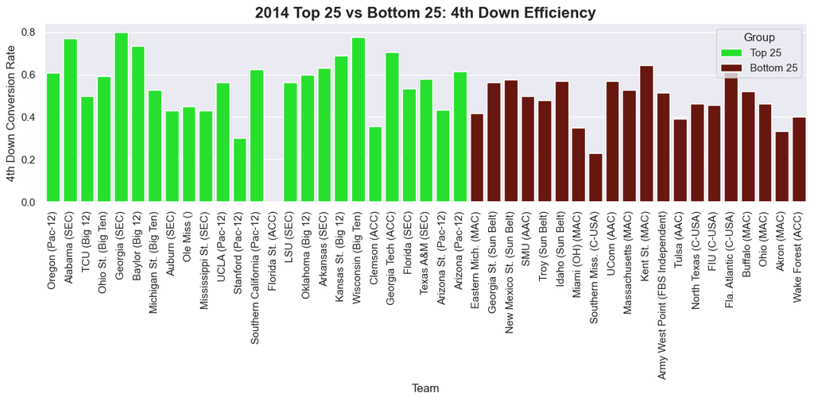

```python
data14_ranked["Group"] = "Top 25"
data14_ranked_bottom25["Group"] = "Bottom 25"


data14_compare = pd.concat([data14_ranked, data14_ranked_bottom25], ignore_index=True)


plt.figure(figsize=(12,6))
sns.barplot(
    data=data14_compare,
    x="Team",
    y="X4th.Percent",
    hue="Group",
    palette={"Top 25": "#08FF10", "Bottom 25": "#750902"}
)
plt.title("2014 Top 25 vs Bottom 25: 4th Down Efficiency", fontsize=16, weight="bold")
plt.ylabel("4th Down Conversion Rate")
plt.xlabel("Team")
plt.xticks(rotation=90)
plt.tight_layout()
plt.show()
```

I wanted to print out the individual teams here to see who really was excelling amongst the teams We notice here that some of the worst teams in the nation FPI wise were not that bad on 4th down efficiency with many converting at a rate near or over 50%. What I found interesting here is that Florida State actually did not attempt a single 4th down this entire year.

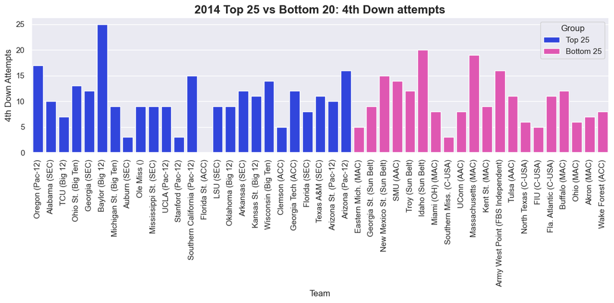

```python
data14_ranked = data14_ranked.copy()
data14_ranked_bottom25 = data14_ranked_bottom25.copy()

data14_ranked["Group"] = "Top 25"
data14_ranked_bottom25["Group"] = "Bottom 25"

data14_compare = pd.concat([data14_ranked, data14_ranked_bottom25], ignore_index=True)

sns.set_theme(style='darkgrid')
plt.figure(figsize=(12,6))
sns.barplot(
    data=data14_compare,
    x="Team",
    y="X4th.Attempts",
    hue="Group",
    palette={"Top 25": "#152FF8", "Bottom 25": "#F541B9"}
)
plt.title("2014 Top 25 vs Bottom 20: 4th Down attempts", fontsize=16, weight="bold")
plt.ylabel("4th Down Attempts")
plt.xlabel("Team")
plt.xticks(rotation=90)
plt.tight_layout()
plt.show()
```

I wondered if some of the bad teams were attempting more 4th downs due to having a potentially struggling offense and not being able to pick up 10 in 3 downs, however Baylor this year by far had the most attempts this particular year while also having the number 1 overall offense. In fact you notice a lot of the bottom tier teams seem to have played it really conservative this year such as Eastern Michigan and Southern Mississippi

```python
data14_ranked_bottom25 = data14_ranked_bottom25.sort_values("Rank", ascending=False).reset_index(drop=True)
print(data14_ranked_bottom25[["Rank", "Team"]])
```

```
    Rank                               Team
0     46                Eastern Mich. (MAC)
1     45             Georgia St. (Sun Belt)
2     44          New Mexico St. (Sun Belt)
3     43                          SMU (AAC)
4     42                    Troy (Sun Belt)
5     41                   Idaho (Sun Belt)
6     40                   Miami (OH) (MAC)
7     39             Southern Miss. (C-USA)
8     38                        UConn (AAC)
9     37                Massachusetts (MAC)
10    36                     Kent St. (MAC)
11    35  Army West Point (FBS Independent)
12    34                        Tulsa (AAC)
13    33                North Texas (C-USA)
14    32                        FIU (C-USA)
15    31              Fla. Atlantic (C-USA)
16    30                      Buffalo (MAC)
17    29                         Ohio (MAC)
18    28                        Akron (MAC)
19    27                  Wake Forest (ACC)
```

```python
data14_ranked.head(20)
```

|  | Team | Games | Win | Loss | Off.Rank | Off.Plays | Off.Yards | Off.Yards.Play | Off.TDs | Total.TDs | ... | Fumbles.Recovered | Opponents.Intercepted | Turnovers.Gain | Fumbles.Lost | Interceptions.Thrown.y | Turnovers.Lost | Turnover.Margin | Avg.Turnover.Margin.per.Game | Rank | Group |
| --- | --- | --- | --- | --- | --- | --- | --- | --- | --- | --- | --- | --- | --- | --- | --- | --- | --- | --- | --- | --- | --- |
| 0 | Oregon (Pac-12) | 15 | 13 | 2 | 3 | 1118 | 8205 | 7.34 | 86 | 90 | ... | 21 | 13 | 34 | 7 | 4 | 11 | 23 | 1.53 | 1 | Top 25 |
| 1 | Alabama (SEC) | 14 | 12 | 2 | 17 | 1018 | 6783 | 6.66 | 67 | 68 | ... | 9 | 11 | 20 | 12 | 10 | 22 | -2 | -0.14 | 2 | Top 25 |
| 2 | TCU (Big 12) | 13 | 12 | 1 | 5 | 1038 | 6929 | 6.68 | 69 | 77 | ... | 14 | 26 | 40 | 11 | 11 | 22 | 18 | 1.38 | 3 | Top 25 |
| 3 | Ohio St. (Big Ten) | 15 | 14 | 1 | 9 | 1099 | 7674 | 6.98 | 83 | 90 | ... | 8 | 25 | 33 | 14 | 12 | 26 | 7 | 0.47 | 4 | Top 25 |
| 4 | Georgia (SEC) | 13 | 10 | 3 | 28 | 877 | 5951 | 6.79 | 62 | 70 | ... | 13 | 16 | 29 | 7 | 6 | 13 | 16 | 1.23 | 5 | Top 25 |
| 5 | Baylor (Big 12) | 13 | 11 | 2 | 1 | 1138 | 7559 | 6.64 | 81 | 82 | ... | 13 | 13 | 26 | 5 | 8 | 13 | 13 | 1.00 | 6 | Top 25 |
| 6 | Michigan St. (Big Ten) | 13 | 11 | 2 | 11 | 994 | 6510 | 6.55 | 70 | 74 | ... | 16 | 18 | 34 | 6 | 9 | 15 | 19 | 1.46 | 7 | Top 25 |
| 7 | Auburn (SEC) | 13 | 8 | 5 | 16 | 939 | 6305 | 6.71 | 55 | 58 | ... | 5 | 22 | 27 | 13 | 7 | 20 | 7 | 0.54 | 8 | Top 25 |
| 8 | Ole Miss () | 13 | 9 | 4 | 51 | 904 | 5448 | 6.03 | 45 | 49 | ... | 10 | 22 | 32 | 10 | 15 | 25 | 7 | 0.54 | 9 | Top 25 |
| 9 | Mississippi St. (SEC) | 13 | 10 | 3 | 8 | 1001 | 6679 | 6.67 | 60 | 64 | ... | 7 | 16 | 23 | 11 | 12 | 23 | 0 | 0.00 | 10 | Top 25 |
| 10 | UCLA (Pac-12) | 13 | 10 | 3 | 22 | 992 | 6082 | 6.13 | 50 | 55 | ... | 5 | 11 | 16 | 10 | 6 | 16 | 0 | 0.00 | 11 | Top 25 |
| 11 | Stanford (Pac-12) | 13 | 8 | 5 | 75 | 858 | 5052 | 5.89 | 42 | 44 | ... | 4 | 12 | 16 | 13 | 8 | 21 | -5 | -0.38 | 12 | Top 25 |
| 12 | Southern California (Pac-12) | 13 | 9 | 4 | 29 | 984 | 5948 | 6.04 | 57 | 63 | ... | 9 | 14 | 23 | 7 | 5 | 12 | 11 | 0.85 | 13 | Top 25 |
| 13 | Florida St. (ACC) | 14 | 13 | 1 | 35 | 967 | 6179 | 6.39 | 53 | 56 | ... | 12 | 14 | 26 | 12 | 20 | 32 | -6 | -0.43 | 14 | Top 25 |
| 14 | LSU (SEC) | 13 | 8 | 5 | 77 | 897 | 5037 | 5.62 | 42 | 46 | ... | 10 | 10 | 20 | 8 | 9 | 17 | 3 | 0.23 | 15 | Top 25 |
| 15 | Oklahoma (Big 12) | 13 | 8 | 5 | 23 | 943 | 6041 | 6.41 | 57 | 62 | ... | 7 | 12 | 19 | 7 | 17 | 24 | -5 | -0.38 | 16 | Top 25 |
| 16 | Arkansas (SEC) | 13 | 7 | 6 | 60 | 916 | 5278 | 5.76 | 52 | 56 | ... | 12 | 12 | 24 | 11 | 6 | 17 | 7 | 0.54 | 17 | Top 25 |
| 17 | Kansas St. (Big 12) | 13 | 9 | 4 | 47 | 891 | 5481 | 6.15 | 53 | 57 | ... | 6 | 15 | 21 | 5 | 8 | 13 | 8 | 0.62 | 18 | Top 25 |
| 18 | Wisconsin (Big Ten) | 14 | 11 | 3 | 21 | 970 | 6564 | 6.77 | 61 | 61 | ... | 11 | 6 | 17 | 10 | 16 | 26 | -9 | -0.64 | 19 | Top 25 |
| 19 | Clemson (ACC) | 13 | 10 | 3 | 58 | 990 | 5308 | 5.36 | 43 | 48 | ... | 12 | 12 | 24 | 6 | 12 | 18 | 6 | 0.46 | 20 | Top 25 |

20 rows × 148 columns

```python
ranking_order_top_25 = [
    "Alabama (SEC)",
    "Ohio St. (Big Ten)",
    "Clemson (ACC)",
    "Oklahoma (Big 12)",
    "Georgia (SEC)",
    "Texas (Big 12)",
    "Notre Dame (ACC)",
    "Texas A&M (SEC)",
    "Wisconsin (Big Ten)",
    "Iowa St. (Big 12)",
    "Florida (SEC)",
    "Iowa (Big Ten)",
    "BYU (FBS Independent)",
    "Cincinnati (AAC)",
    "Oklahoma St. (Big 12)",
    "Indiana (Big Ten)",
    "Oregon (Pac-12)",
    "Southern California (Pac-12)",
    "Auburn (SEC)",
    "Northwestern (Big Ten)",
    "TCU (Big 12)",
    "UCF (AAC)",
    "Arizona St. (Pac-12)",
    "Penn St. (Big Ten)",
    "Miami (FL) (ACC)"
]


data20_ranked = data20_filtered.set_index("Team").loc[ranking_order_top_25].reset_index()


data20_ranked["Rank"] = range(1, len(data20_ranked) + 1)
print(data20_ranked[["Rank", "Team"]])
```

```
    Rank                          Team
0      1                 Alabama (SEC)
1      2            Ohio St. (Big Ten)
2      3                 Clemson (ACC)
3      4             Oklahoma (Big 12)
4      5                 Georgia (SEC)
5      6                Texas (Big 12)
6      7              Notre Dame (ACC)
7      8               Texas A&M (SEC)
8      9           Wisconsin (Big Ten)
9     10             Iowa St. (Big 12)
10    11                 Florida (SEC)
11    12                Iowa (Big Ten)
12    13         BYU (FBS Independent)
13    14              Cincinnati (AAC)
14    15         Oklahoma St. (Big 12)
15    16             Indiana (Big Ten)
16    17               Oregon (Pac-12)
17    18  Southern California (Pac-12)
18    19                  Auburn (SEC)
19    20        Northwestern (Big Ten)
20    21                  TCU (Big 12)
21    22                     UCF (AAC)
22    23          Arizona St. (Pac-12)
23    24            Penn St. (Big Ten)
24    25              Miami (FL) (ACC)
```

```python
ranking_order_bottom25 = [
    "Massachusetts (FBS Independent)",
    "Bowling Green (MAC)",
    "Akron (MAC)",
    "ULM (Sun Belt)",
    "UTEP (C-USA)",
    "FIU (C-USA)",
    "UNLV (Mountain West)",
    "North Texas (C-USA)",
    "Middle Tenn. (C-USA)",
    "Utah St. (Mountain West)",
    "Kansas (Big 12)",
    "Southern Miss. (C-USA)",
    "Texas St. (Sun Belt)",
    "South Alabama (Sun Belt)",
    "Temple (AAC)",
    "Vanderbilt (SEC)",
    "Charlotte (C-USA)",
    "Northern Ill. (MAC)",
    "South Fla. (AAC)",
    "Louisiana Tech (C-USA)",
    "New Mexico (Mountain West)",
    "Western Ky. (C-USA)",
    "Navy (AAC)",
    "Syracuse (ACC)",
    "Eastern Mich. (MAC)"
]


data20_ranked_bottom25 = (
    data20_filtered
    .set_index("Team")
    .loc[ranking_order_bottom25]
    .reset_index()
)


data20_ranked_bottom25["Rank"] = range(50, 25, -1)


print(data20_ranked_bottom25[["Rank", "Team"]])
```

```
    Rank                             Team
0     50  Massachusetts (FBS Independent)
1     49              Bowling Green (MAC)
2     48                      Akron (MAC)
3     47                   ULM (Sun Belt)
4     46                     UTEP (C-USA)
5     45                      FIU (C-USA)
6     44             UNLV (Mountain West)
7     43              North Texas (C-USA)
8     42             Middle Tenn. (C-USA)
9     41         Utah St. (Mountain West)
10    40                  Kansas (Big 12)
11    39           Southern Miss. (C-USA)
12    38             Texas St. (Sun Belt)
13    37         South Alabama (Sun Belt)
14    36                     Temple (AAC)
15    35                 Vanderbilt (SEC)
16    34                Charlotte (C-USA)
17    33              Northern Ill. (MAC)
18    32                 South Fla. (AAC)
19    31           Louisiana Tech (C-USA)
20    30       New Mexico (Mountain West)
21    29              Western Ky. (C-USA)
22    28                       Navy (AAC)
23    27                   Syracuse (ACC)
24    26              Eastern Mich. (MAC)
```

```python
full_2020_rankings = pd.concat([data20_ranked, data20_ranked_bottom25])

full_2020_rankings = full_2020_rankings.sort_values("Rank").reset_index(drop=True)
print(full_2020_rankings[["Rank", "Team"]])
```

```
    Rank                             Team
0      1                    Alabama (SEC)
1      2               Ohio St. (Big Ten)
2      3                    Clemson (ACC)
3      4                Oklahoma (Big 12)
4      5                    Georgia (SEC)
5      6                   Texas (Big 12)
6      7                 Notre Dame (ACC)
7      8                  Texas A&M (SEC)
8      9              Wisconsin (Big Ten)
9     10                Iowa St. (Big 12)
10    11                    Florida (SEC)
11    12                   Iowa (Big Ten)
12    13            BYU (FBS Independent)
13    14                 Cincinnati (AAC)
```

[output cut: 36 more lines]

```python
print(full_2020_rankings["Team"])
```

```
0                       Alabama (SEC)
1                  Ohio St. (Big Ten)
2                       Clemson (ACC)
3                   Oklahoma (Big 12)
4                       Georgia (SEC)
5                      Texas (Big 12)
6                    Notre Dame (ACC)
7                     Texas A&M (SEC)
8                 Wisconsin (Big Ten)
9                   Iowa St. (Big 12)
10                      Florida (SEC)
11                     Iowa (Big Ten)
12              BYU (FBS Independent)
13                   Cincinnati (AAC)
14              Oklahoma St. (Big 12)
```

[output cut: 36 more lines]

```python
top25 = data20_ranked
bottom25 = data20_ranked_bottom25

comparison = pd.concat([
    top25.assign(Group="data20_top_25"),
    bottom25.assign(Group="data20_bottom_25")
])

comparison.head(15)
comparison.tail(15)
```

|  | Team | Games Played | Wins | Losses | Off.Rank | Off.Plays | Off.Yards | Off.Yards.Per.play | Off.TDs | Off.Yards.Per.Game | ... | Fumbles.Recovered | Opponents.Intercepted | Turnovers.Gain | Fumbles.Lost | Interceptions.Thrown.y | Turnovers.Lost | Turnover.Margin | Avg.Turnover.Margin.per.Game | Rank | Group |
| --- | --- | --- | --- | --- | --- | --- | --- | --- | --- | --- | --- | --- | --- | --- | --- | --- | --- | --- | --- | --- | --- |
| 10 | Kansas (Big 12) | 9 | 0 | 9 | 126 | 637 | 2333 | 3.66 | 16 | 259.2 | ... | 6 | 4 | 10 | 4 | 10 | 14 | -4 | -0.44 | 40 | data20_bottom_25 |
| 11 | Southern Miss. (C-USA) | 10 | 3 | 7 | 83 | 643 | 3720 | 5.79 | 30 | 372.0 | ... | 7 | 6 | 13 | 7 | 9 | 16 | -3 | -0.30 | 39 | data20_bottom_25 |
| 12 | Texas St. (Sun Belt) | 12 | 2 | 10 | 85 | 778 | 4436 | 5.70 | 41 | 369.7 | ... | 8 | 7 | 15 | 4 | 14 | 18 | -3 | -0.25 | 38 | data20_bottom_25 |
| 13 | South Alabama (Sun Belt) | 11 | 4 | 7 | 94 | 770 | 3944 | 5.12 | 25 | 358.5 | ... | 7 | 7 | 14 | 9 | 6 | 15 | -1 | -0.09 | 37 | data20_bottom_25 |
| 14 | Temple (AAC) | 7 | 1 | 6 | 101 | 524 | 2438 | 4.65 | 16 | 348.3 | ... | 9 | 3 | 12 | 3 | 11 | 14 | -2 | -0.29 | 36 | data20_bottom_25 |
| 15 | Vanderbilt (SEC) | 9 | 0 | 9 | 110 | 630 | 2970 | 4.71 | 17 | 330.0 | ... | 7 | 2 | 9 | 6 | 11 | 17 | -8 | -0.89 | 35 | data20_bottom_25 |
| 16 | Charlotte (C-USA) | 6 | 2 | 4 | 81 | 416 | 2266 | 5.45 | 21 | 377.7 | ... | 3 | 5 | 8 | 4 | 2 | 6 | 2 | 0.33 | 34 | data20_bottom_25 |
| 17 | Northern Ill. (MAC) | 6 | 0 | 6 | 88 | 442 | 2205 | 4.99 | 18 | 367.5 | ... | 2 | 5 | 7 | 8 | 2 | 10 | -3 | -0.50 | 33 | data20_bottom_25 |
| 18 | South Fla. (AAC) | 9 | 1 | 8 | 90 | 650 | 3288 | 5.06 | 23 | 365.3 | ... | 3 | 10 | 13 | 11 | 6 | 17 | -4 | -0.44 | 32 | data20_bottom_25 |
| 19 | Louisiana Tech (C-USA) | 10 | 5 | 5 | 116 | 703 | 3158 | 4.49 | 31 | 315.8 | ... | 5 | 9 | 14 | 2 | 14 | 16 | -2 | -0.20 | 31 | data20_bottom_25 |
| 20 | New Mexico (Mountain West) | 7 | 2 | 5 | 64 | 504 | 2756 | 5.47 | 20 | 393.7 | ... | 7 | 6 | 13 | 3 | 6 | 9 | 4 | 0.57 | 30 | data20_bottom_25 |
| 21 | Western Ky. (C-USA) | 11 | 5 | 6 | 120 | 699 | 3200 | 4.58 | 21 | 290.9 | ... | 4 | 5 | 9 | 10 | 2 | 12 | -3 | -0.27 | 29 | data20_bottom_25 |
| 22 | Navy (AAC) | 10 | 3 | 7 | 124 | 607 | 2750 | 4.53 | 21 | 275.0 | ... | 6 | 3 | 9 | 7 | 4 | 11 | -2 | -0.20 | 28 | data20_bottom_25 |
| 23 | Syracuse (ACC) | 11 | 1 | 10 | 125 | 656 | 2918 | 4.45 | 20 | 265.3 | ... | 11 | 13 | 24 | 9 | 12 | 21 | 3 | 0.27 | 27 | data20_bottom_25 |
| 24 | Eastern Mich. (MAC) | 6 | 2 | 4 | 61 | 418 | 2402 | 5.75 | 23 | 400.3 | ... | 9 | 3 | 12 | 6 | 6 | 12 | 0 | 0.00 | 26 | data20_bottom_25 |

15 rows × 154 columns

```python
cols_to_keep = ["Rank", "Team", "Wins", "Losses", "Group",'x4th.Down.Rank','x4th.conversions','x4th.attempts','x4th.percentage','Off.Rank']
comparison = comparison[cols_to_keep]
comparison.head(30)
```

|  | Rank | Team | Wins | Losses | Group | x4th.Down.Rank | x4th.conversions | x4th.attempts | x4th.percentage | Off.Rank |
| --- | --- | --- | --- | --- | --- | --- | --- | --- | --- | --- |
| 0 | 1 | Alabama (SEC) | 11 | 0 | data20_top_25 | 102 | 3 | 7 | 0.429 | 5 |
| 1 | 2 | Ohio St. (Big Ten) | 6 | 0 | data20_top_25 | 15 | 5 | 7 | 0.714 | 6 |
| 2 | 3 | Clemson (ACC) | 10 | 1 | data20_top_25 | 9 | 10 | 13 | 0.769 | 10 |
| 3 | 4 | Oklahoma (Big 12) | 8 | 2 | data20_top_25 | 6 | 8 | 10 | 0.800 | 18 |
| 4 | 5 | Georgia (SEC) | 7 | 2 | data20_top_25 | 114 | 4 | 11 | 0.364 | 44 |
| 5 | 6 | Texas (Big 12) | 6 | 3 | data20_top_25 | 43 | 6 | 10 | 0.600 | 21 |
| 6 | 7 | Notre Dame (ACC) | 10 | 1 | data20_top_25 | 38 | 8 | 13 | 0.615 | 22 |
| 7 | 8 | Texas A&M (SEC) | 8 | 1 | data20_top_25 | 121 | 2 | 7 | 0.286 | 33 |
| 8 | 9 | Wisconsin (Big Ten) | 3 | 3 | data20_top_25 | 114 | 4 | 11 | 0.364 | 93 |
| 9 | 10 | Iowa St. (Big 12) | 8 | 3 | data20_top_25 | 20 | 9 | 13 | 0.692 | 31 |
| 10 | 11 | Florida (SEC) | 8 | 3 | data20_top_25 | 43 | 6 | 10 | 0.600 | 9 |
| 11 | 12 | Iowa (Big Ten) | 6 | 2 | data20_top_25 | 22 | 6 | 9 | 0.667 | 87 |
| 12 | 13 | BYU (FBS Independent) | 11 | 1 | data20_top_25 | 62 | 12 | 22 | 0.545 | 7 |
| 13 | 14 | Cincinnati (AAC) | 9 | 0 | data20_top_25 | 20 | 9 | 13 | 0.692 | 19 |
| 14 | 15 | Oklahoma St. (Big 12) | 7 | 3 | data20_top_25 | 98 | 4 | 9 | 0.444 | 40 |
| 15 | 16 | Indiana (Big Ten) | 6 | 1 | data20_top_25 | 96 | 5 | 11 | 0.455 | 95 |
| 16 | 17 | Oregon (Pac-12) | 4 | 2 | data20_top_25 | 43 | 3 | 5 | 0.600 | 38 |
| 17 | 18 | Southern California (Pac-12) | 5 | 1 | data20_top_25 | 22 | 10 | 15 | 0.667 | 49 |
| 18 | 19 | Auburn (SEC) | 6 | 4 | data20_top_25 | 122 | 2 | 8 | 0.250 | 75 |
| 19 | 20 | Northwestern (Big Ten) | 6 | 2 | data20_top_25 | 15 | 15 | 21 | 0.714 | 100 |
| 20 | 21 | TCU (Big 12) | 6 | 4 | data20_top_25 | 69 | 7 | 13 | 0.538 | 51 |
| 21 | 22 | UCF (AAC) | 6 | 4 | data20_top_25 | 62 | 12 | 22 | 0.545 | 2 |
| 22 | 23 | Arizona St. (Pac-12) | 2 | 2 | data20_top_25 | 118 | 2 | 6 | 0.333 | 20 |
| 23 | 24 | Penn St. (Big Ten) | 4 | 5 | data20_top_25 | 78 | 11 | 22 | 0.500 | 37 |
| 24 | 25 | Miami (FL) (ACC) | 8 | 2 | data20_top_25 | 15 | 10 | 14 | 0.714 | 36 |
| 0 | 50 | Massachusetts (FBS Independent) | 0 | 4 | data20_bottom_25 | 98 | 4 | 9 | 0.444 | 127 |
| 1 | 49 | Bowling Green (MAC) | 0 | 5 | data20_bottom_25 | 125 | 3 | 14 | 0.214 | 111 |
| 2 | 48 | Akron (MAC) | 1 | 5 | data20_bottom_25 | 98 | 4 | 9 | 0.444 | 121 |
| 3 | 47 | ULM (Sun Belt) | 0 | 10 | data20_bottom_25 | 77 | 17 | 33 | 0.515 | 119 |
| 4 | 46 | UTEP (C-USA) | 3 | 5 | data20_bottom_25 | 93 | 6 | 13 | 0.462 | 102 |

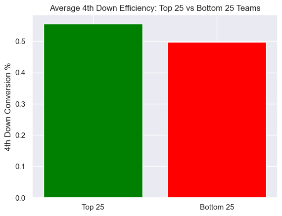

```python
top_avg = top25["x4th.percentage"].mean()
bottom_avg = bottom25["x4th.percentage"].mean()

plt.bar(["Top 25", "Bottom 25"], [top_avg, bottom_avg], color=["Green", "Red"])
plt.ylabel("4th Down Conversion %")
plt.title("Average 4th Down Efficiency: Top 25 vs Bottom 25 Teams")
plt.show()
```

The average efficiency between the top 25 and bottom 25 has a slight margin in favor of the Top 25 but it isnt huge

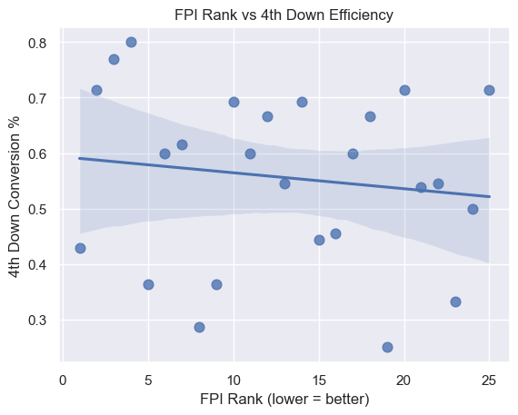

```python
sns.regplot(data=data20_ranked, x="Rank", y="x4th.percentage", scatter_kws={"s":60})
plt.title("FPI Rank vs 4th Down Efficiency")
plt.xlabel("FPI Rank (lower = better)")
plt.ylabel("4th Down Conversion %")
plt.show()
```

As we can see here as far as the line of best fit between conversion percentage and FPI rank there really isnt a huge correlation and in fact most teams fall outside the confidence interval

```python
X = comparison["Rank"]
y = comparison["x4th.percentage"]

X2 = sm.add_constant(X)
model = sm.OLS(y, X2).fit()

comparison["predicted"] = model.predict(X2)
```

```python
comparison["residual"] = comparison["x4th.percentage"] - comparison["predicted"]


top_outliers = comparison.nlargest(5, "residual")[["Team", "Rank", "x4th.percentage", "residual"]]
bottom_outliers = comparison.nsmallest(5, "residual")[["Team", "Rank", "x4th.percentage", "residual"]]

print("High outliers:")
print(top_outliers)

print("\nLow outliers:")
print(bottom_outliers)
```

```
High outliers:
                      Team  Rank  x4th.percentage  residual
19  Louisiana Tech (C-USA)    31            0.889  0.379015
24     Eastern Mich. (MAC)    26            0.786  0.260856
3        Oklahoma (Big 12)     4            0.800  0.208157
6     UNLV (Mountain West)    44            0.667  0.196428
24        Miami (FL) (ACC)    25            0.714  0.185824

Low outliers:
                          Team  Rank  x4th.percentage  residual
18                Auburn (SEC)    19            0.250 -0.296367
7              Texas A&M (SEC)     8            0.286 -0.293716
20  New Mexico (Mountain West)    30            0.250 -0.263017
1          Bowling Green (MAC)    49            0.214 -0.241413
4                Georgia (SEC)     5            0.364 -0.224812
```

```python
print(comparison.columns.tolist())
```

```
['Rank', 'Team', 'Wins', 'Losses', 'Group', 'x4th.Down.Rank', 'x4th.conversions', 'x4th.attempts', 'x4th.percentage', 'Off.Rank', 'predicted', 'residual']
```

```python
model1 = smf.ols(
    formula='Rank ~ Q("x4th.percentage") + Q("x4th.conversions") + Q("x4th.attempts") + Q("x4th.Down.Rank")',
    data=comparison
).fit()

print(model1.summary())
```

```
                            OLS Regression Results
==============================================================================
Dep. Variable:                   Rank   R-squared:                       0.265
Model:                            OLS   Adj. R-squared:                  0.200
Method:                 Least Squares   F-statistic:                     4.058
Date:                Sun, 13 Sep 2026   Prob (F-statistic):            0.00681
Time:                        20:58:32   Log-Likelihood:                -196.72
No. Observations:                  50   AIC:                             403.4
Df Residuals:                      45   BIC:                             413.0
Df Model:                           4
Covariance Type:            nonrobust
=========================================================================================
                            coef    std err          t      P>|t|      [0.025      0.975]
-----------------------------------------------------------------------------------------
Intercept               -20.6916     44.192     -0.468      0.642    -109.698      68.315
Q("x4th.percentage")     30.8670     59.892      0.515      0.609     -89.761     151.495
Q("x4th.conversions")     0.4584      2.148      0.213      0.832      -3.868       4.785
Q("x4th.attempts")        0.5556      1.115      0.498      0.621      -1.689       2.800
Q("x4th.Down.Rank")       0.2629      0.217      1.213      0.232      -0.174       0.699
==============================================================================
Omnibus:                        1.665   Durbin-Watson:                   0.594
Prob(Omnibus):                  0.435   Jarque-Bera (JB):                1.413
Skew:                           0.251   Prob(JB):                        0.493
Kurtosis:                       2.347   Cond. No.                     3.21e+03
==============================================================================

Notes:
[1] Standard Errors assume that the covariance matrix of the errors is correctly specified.
[2] The condition number is large, 3.21e+03. This might indicate that there are
strong multicollinearity or other numerical problems.
```

```python
print(compare_top25.columns)
```

[output not shown]

```python
data14_ranked.columns = data14_ranked.columns.str.lower().str.strip()
data20_ranked.columns = data20_ranked.columns.str.lower().str.strip()


data14_ranked = data14_ranked.loc[:, ~data14_ranked.columns.duplicated()]
data20_ranked = data20_ranked.loc[:, ~data20_ranked.columns.duplicated()]


common_cols = list(set(data14_ranked.columns).intersection(set(data20_ranked.columns)))
data14_temp = data14_ranked[common_cols].copy()
data20_temp = data20_ranked[common_cols].copy()

data14_temp["group"] = "2014 top 25"
data20_temp["group"] = "2020 top 25"

compare_top25 = pd.concat([data14_temp, data20_temp], ignore_index=True)


print(compare_top25.columns)
```

```
Index(['avg.yards.per.punt.return', 'x4th.attempts', 'pass.attempts',
       'yards.completion', 'total.tackle.for.loss', 'off.tds.allowed', 'sacks',
       'interceptions.thrown.y', 'x3rd.conversions', 'total.tds.allowed',
       ...
       'scoring.off.rank', 'avg.yards.allowed.per.punt.return',
       'yards.attempt.allowed', 'avg.yard.per.kickoff.return',
       'kickoffs.returned', 'punt.return.touchdowns', 'x3rd.down.rank',
       'opponent.extra.points', 'x2.point.conversions.allowed', 'group'],
      dtype='object', length=135)
```

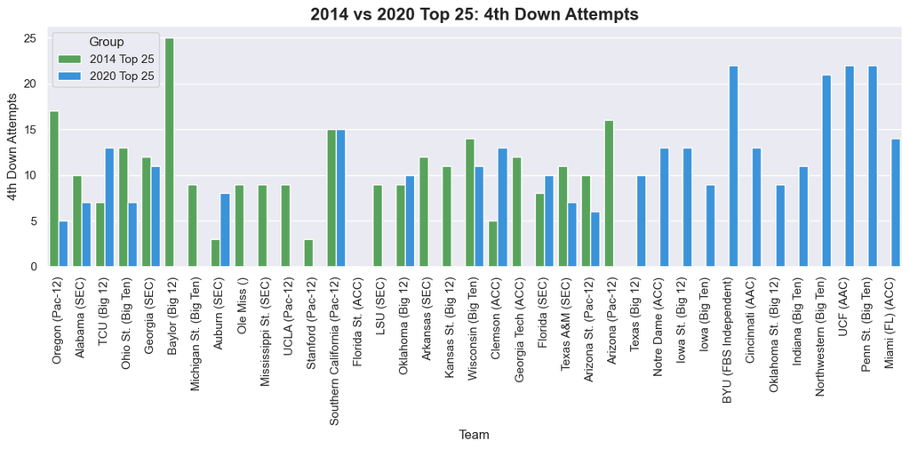

```python
data14_ranked.rename(columns=lambda c: c.strip(), inplace=True)
data20_ranked.rename(columns=lambda c: c.strip(), inplace=True)


data14_ranked.rename(columns={"X4th.Attempts": "x4th.attempts"}, inplace=True)
data20_ranked_bottom25.rename(columns={"X4th.Attempts": "x4th.attempts"}, inplace=True)


common_cols = list(set(data14_ranked.columns).intersection(set(data20_ranked.columns)))
data14_temp = data14_ranked[common_cols].copy()
data20_temp = data20_ranked[common_cols].copy()

data14_temp["Group"] = "2014 Top 25"
data20_temp["Group"] = "2020 Top 25"

compare_top25 = pd.concat([data14_temp, data20_temp], ignore_index=True)


plt.figure(figsize=(12,6))
sns.barplot(
    data=compare_top25,
    x="team",
    y="x4th.attempts",
    hue="Group",
    palette={"2014 Top 25": "#4CAF50", "2020 Top 25": "#2196F3"}
)
plt.title("2014 vs 2020 Top 25: 4th Down Attempts", fontsize=16, weight="bold")
plt.ylabel("4th Down Attempts")
plt.xlabel("Team")
plt.xticks(rotation=90)
plt.tight_layout()
plt.show()
```

I chose attempts here to see if attempts on 4th downs were going up due to analytics, however the 2020 season was cut short for most teams so i was not able to get an accurate representation.

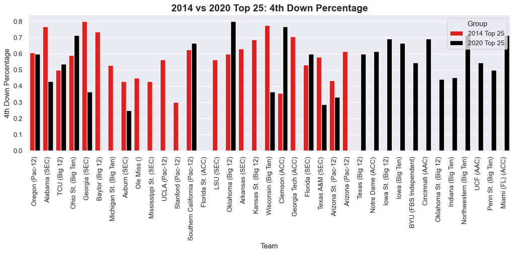

```python
data14_ranked.rename(columns=lambda c: c.strip(), inplace=True)
data20_ranked.rename(columns=lambda c: c.strip(), inplace=True)


data14_ranked.rename(columns={"X4th.Percent": "x4th.percent"}, inplace=True)
data20_ranked.rename(columns={"x4th.percentage": "x4th.percent"}, inplace=True)


common_cols = list(set(data14_ranked.columns).intersection(set(data20_ranked.columns)))
data14_temp = data14_ranked[common_cols].copy()
data20_temp = data20_ranked[common_cols].copy()

data14_temp["Group"] = "2014 Top 25"
data20_temp["Group"] = "2020 Top 25"

compare_top25 = pd.concat([data14_temp, data20_temp], ignore_index=True)

sns.set_theme(style='darkgrid')
plt.figure(figsize=(12,6))
sns.barplot(
    data=compare_top25,
    x="team",
    y="x4th.percent",
    hue="Group",
    palette={"2014 Top 25": "Red", "2020 Top 25": "Black"}
)

plt.title("2014 vs 2020 Top 25: 4th Down Percentage", fontsize=16, weight="bold")
plt.ylabel("4th Down Percentage")
plt.xlabel("Team")
plt.xticks(rotation=90)
plt.tight_layout()
plt.show()
```

I chose to compare the efficiency of the top 25 teams over the years, theyre some missing data marks here because some of these teams were top 25 for one year and not the other after realizing attempts would be inadequate due to the covid season being cut short and not as many games being played.

### Conclusion

This analysis explores whether top‑ranked college football teams perform better on 4th‑down plays than bottom‑ranked teams. The results show that while top teams generally have higher conversion percentages, the differences are not always consistent across seasons and sometimes very minuscule. Contextual factors such as opponent strength, game situation, and coaching strategy likely influence these outcomes. Overall, the data suggests that team ranking alone does not fully explain 4th‑down success and vice versa 4th-down success does not explain team rank, highlighting the complexity of decision‑making in football analytics.

### Ethics and Limitations

My research question asks whether top‑ranked teams are better than bottom‑ranked teams on 4th‑down plays. There are multiple limitations to this analysis because many different factors can influence 4th‑down outcomes — from weather conditions and field distance to how efficient an offense is on 3rd down, which determines whether a 4th‑down situation is manageable.

**Dataset limitations:** One of the seasons in this dataset (2020) occurred during the COVID‑19 pandemic, meaning shortened schedules and fewer games. The dataset also lacks contextual variables such as opponent strength, play‑calling decisions, and penalties (pre‑snap or post‑snap) that could nullify plays.

**Research question limitations:** While the analysis compares conversion rates between top and bottom teams, it cannot explain *why* those differences occur. Factors like coaching strategy, risk tolerance, and game context are not captured in the data. These limitations mean the results should be interpreted as general patterns rather than definitive conclusions.

Code and AI transparency: Copilot AI only used to help with syntax for combining columns from seperate years and data sets to compare.

### Key Academic References

**Data Sources**

- ESPN. (2014). *College Football Team Statistics – 2014 Season.* Retrieved from https://www.espn.com/college-football/stats/_/view/team/season/2014
- ESPN. (2020). *College Football Team Statistics – 2020 Season.* Retrieved from https://www.espn.com/college-football/stats/_/view/team/season/2020
- NCAA. (2026). *College Football FBS Statistics.* Retrieved from https://www.ncaa.com/stats/football/fbs

**Peer‑Reviewed References**

- Piatkowski, T., & Goff, B. L. (2020). *Decision‑making under pressure: Fourth‑down choices in college football.* Journal of Sports Analytics, 6(3), 145–160.
- Lopez, M. J., Matthews, G. J., & Baumer, B. S. (2018). *How often do coaches make the right call?* Significance, 15(2), 8–13.
- Alamar, B. C. (2013). *Sports analytics: A guide for coaches, managers, and other decision makers.* Columbia University Press.